# BIOS 635: Linear and Quadratice Discriminant Analysis

Kevin Donovan

1/28/2021

# Review

- Homework 2 due on 2/4 at 11PM through GitHub Classroom
- Article Evaluation 1 assigned, due on 2/9 through GitHub Classroom
- Last lecture: logistic regression

# Classification

Let response $Y \in \{0,1\}$

**Goal**: Predict $Y$ using features $X$

**What to model?**:

Let $p_k(x)=\text{Pr}(Y=k|X=x)$, $k=0,1$

Denoted as the **conditional class probabilities** at $x$

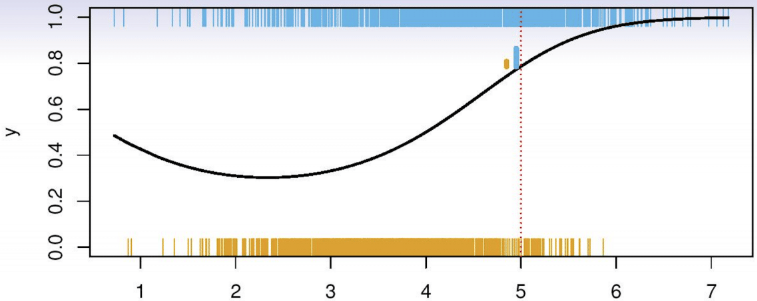

# Discriminant analysis

- **Idea**: Instead of looking at $f(y|x)$, look at $f(x|y)$ for each class $y=1,2,\ldots,K$
- Try to see if distribution of features $X$ **differs** among the response classes
- Then use *Bayes theorem* to estimate $f(y|x)=\text{Pr}(Y=y|X=x)$
- How to model distribution of $f(x|y)$ given many features $X$?
- *Linear/Quadratic Discriminant Analysis* (L/QDA) $\rightarrow$ normal distribution modeled
  - Can be used with other distributions as well

# Bayes Theorm

- Suppose $Y$ and $X$ are discrete/categorical random variables
- **Bayes Theorem**:

$$\text{Pr}(Y=k|X=x)=\frac{\text{Pr}(X=x|Y=k)*\text{Pr}(Y=k)}{\text{Pr}(X=x)}$$

- Also holds for $Y$ and or $X$ continuous:

$$\text{Pr}(Y=k|X=x)=\frac{f(x|k)*\text{Pr}(Y=k)}{f(x)}$$

where

- $f(x|k)$ denotes the conditional density of $X|Y$
- $f(x)$ denotes the density of $X$

# Bayes Theorm for Classification

- We can reformulate this for discriminant analysis:

$$\text{Pr}(Y=k|X=x)=\frac{f(x|k)*\text{Pr}(Y=k)}{\sum_{l=1}^{K} f(x|l)*\text{Pr}(Y=l)}$$

- $f(x|l)$ modeled using a chosen distribution (Normal in our case)
- In Bayes, $\text{Pr}(Y=k)$ denoted as the *prior* probability for class *k*
  - i.e., probability not based on features $X=x$

# Posterior Probability

- In Bayes, $\text{Pr}(Y=k|X=x)$ denoted as *posterior probability*
  - i.e. probability of being in class $k$ based on features $X=x$ (“post” seeing data)
- **Idea**: To classify an observation with feature set $x_0$, choose class with max posterior probability
- i.e., $\hat{y_0}=\underset{k=1,\ldots,K}{\operatorname{argmax}}\frac{f(x_0|k)*\text{Pr}(Y=k)}{\sum_{l=1}^{K} f(x_0|l)*\text{Pr}(Y=l)}$
- This rule is the same rule as used in logistic regression, KNN, etc.
  - **Difference**: Computing conditional probability differently
- **Note**: Denominator is the same for each posterior probability
  - $\rightarrow$ $\hat{y_0}=\underset{k=1,\ldots,K}{\operatorname{argmax}}f(x_0|k)*\text{Pr}(Y=k)$

# Why discriminant analysis?

- Logistic regression limitations:
  - Classes are well-separated $\rightarrow$ logistic regression model unstable
  - Not well suited for multi-category response prediction (required many models)
- Discriminant analysis (DA) improves on stability and well-suited for multi-category response
- If $n$ is small and $X$ $\sim$ Normal in each class, DA more stable

# LDA when $p=1$

- Univariate Normal density:

$$f(x|k)=\frac{1}{\sqrt{2\pi}\sigma_k}e^{-0.5(\frac{x-\mu_k}{\sigma_k})^2}$$

where $\mu_k=\text{E}(X|Y=k)$ and $\sigma_k=\sqrt{\text{Var}(X|Y=k)}=\text{SD}(X|Y=k)$

- **With LDA** assume $\sigma_k=\sigma$ for all $k=1,\ldots,K$
  - i.e. assume variance/SD in feature same in all response classes

# LDA when $p=1$

- We can plug the above into our posterior probability formula from before:

$$\text{Pr}(Y=k|X=x)=\frac{\text{Pr}(Y=k)\frac{1}{\sqrt{2\pi}\sigma_k}e^{-0.5(\frac{x-\mu_k}{\sigma_k})^2}}{\sum_{l=1}^{K} \text{Pr}(Y=l)\frac{1}{\sqrt{2\pi}\sigma_l}e^{-0.5(\frac{x-\mu_l}{\sigma_l})^2}}$$

# LDA Simplifications

- As done with maximum likelihood, can simplify this max procedure by taking the log
  - $\text{log}[f(x)]$ is **monotonic**, so if $x_0$ maxes $\text{log}[f(x)]$ $\rightarrow$ maxes $f(x)$
- Can also discard terms which don’t involve $k$ (as these are the same for all classes)
- Results in transformation of posterior: $\delta_k(x)$

$$\delta_k(x)=x*\frac{\mu_k}{\sigma^2}-\frac{\mu_k^2}{2\sigma^2}+\text{log}(\pi_k)$$

where $\delta_k(x)=\max\{\delta_1(x), \ldots,\delta_K(x)\}$

$\leftrightarrow$

$\text{Pr}(Y=k|X=x)=\underset{l=1,\ldots,K}{\operatorname{max}}\{\text{Pr}(Y=l|X=x)\}$

# LDA Simplifications

- Thus, can work with $\delta_k(x)$, denoted *discriminant score* instead
- Can see $\delta_k(x)$ is *linear* function of $x$ (hence *linear* DA)
- Can show if $K=2$ and priors $\text{Pr}(Y=1)=\text{Pr}(Y=2)=0.5$, *decision boundary* is at

$$x=\frac{\mu_1+\mu_2}{2}$$

# LDA Visualization

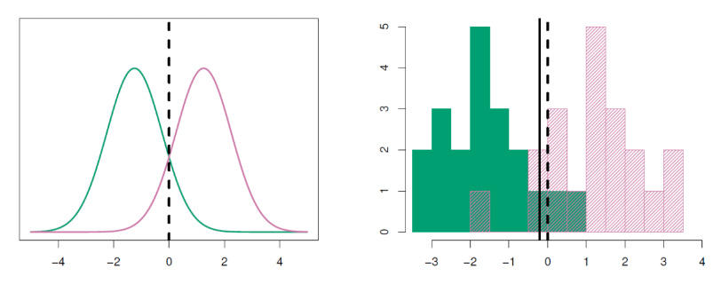

Left (true distribution); Right (estimated from data)

# LDA Estimation

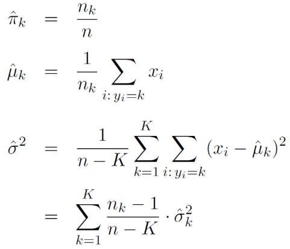

- where $\hat{\sigma_k^2}=\frac{1}{n_k-1}\sum_{i:y_i=k}(x_i-\mu_k)^2$ is the usual estimator for variance in class $k$
  - Pool estimate over all classes due to $\sigma_1^2=\ldots=\sigma_K^2=\sigma^2$

# LDA with $p>1$

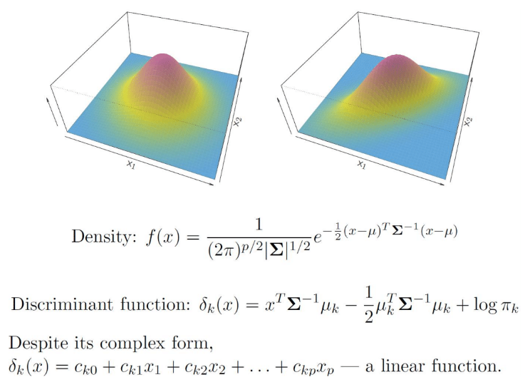

# LDA: Estimating Probabilities

- Given $\hat{\delta_k}(x)$, can compute estimated class probabilities:

$$\hat{\text{Pr}}(Y=k|X=x)=\frac{e^{\hat{\delta}_k(x)}}{\sum_{l=1}^{K}e^{\hat{\delta}_l(x)}}$$

- Just undoing log in probability equation from before by using $e$
- To classify, can use usual rule of largest $\hat{\delta_k}(x)$ $\leftrightarrow$ largest $\hat{\text{Pr}}(Y=k|X=x)$

# Example with $p>1$

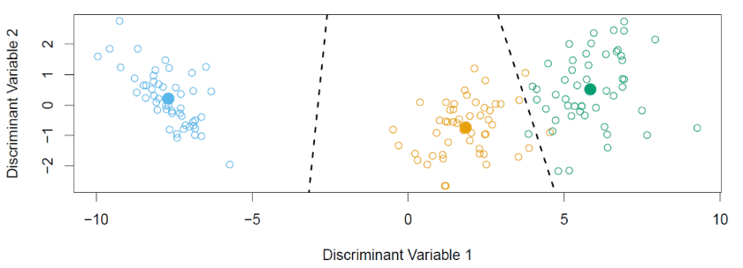

# LDA Example

- Heart disease prediction
- **NOTE**: Do our features follow normal distributions within heart disease status?

```r
# Partition Data
set.seed(12)
train_test_indices <- createDataPartition(heart_data$heart_disease, p=0.6, list = FALSE)
heart_data_train <- heart_data[train_test_indices,]
heart_data_test <- heart_data[-train_test_indices,]

# Train
lda_fit <- train(heart_disease~Age+Sex+Chest_Pain+Resting_Blood_Pressure+Colestrol+
                MAX_Heart_Rate+Exercised_Induced_Angina,
                data = heart_data_train, method = "lda")

# Add in test set predictions
heart_data_test$estimated_prob_heart_disease <-
  predict(lda_fit, newdata=heart_data_test, type = "prob")$Yes

heart_data_test <-
  heart_data_test %>%
  mutate(pred_heart_disease =
           relevel(factor(ifelse(estimated_prob_heart_disease>0.5, "Yes", "No")),
                   ref = "No"))

# Compute confusion matrix
confusionMatrix(data = heart_data_test$pred_heart_disease,
                reference = heart_data_test$heart_disease,
                positive = "Yes")
```

```
## Confusion Matrix and Statistics
##
##           Reference
## Prediction No Yes
##        No  53  19
##        Yes 12  36
##
##                Accuracy : 0.7417
##                  95% CI : (0.6538, 0.8172)
##     No Information Rate : 0.5417
##     P-Value [Acc > NIR] : 5.135e-06
##
##                   Kappa : 0.4746
##
##  Mcnemar's Test P-Value : 0.2812
##
##             Sensitivity : 0.6545
##             Specificity : 0.8154
##          Pos Pred Value : 0.7500
##          Neg Pred Value : 0.7361
##              Prevalence : 0.4583
##          Detection Rate : 0.3000
##    Detection Prevalence : 0.4000
##       Balanced Accuracy : 0.7350
##
##        'Positive' Class : Yes
##
```

# LDA Example: Varying Threshold

- Used a threshold of 0.5, but may see “better” performance using a different one
- Can analyze all thresholds using ROC curve

```r
# Using pROC, add ROC curve using estimated probabilities of heart disease in test set
roc_obj <-
  roc(response = heart_data_test$heart_disease,
    predictor = heart_data_test$estimated_prob_heart_disease)

# Print obj
roc_obj
```

```
##
## Call:
## roc.default(response = heart_data_test$heart_disease, predictor = heart_data_test$estimated_prob_heart_disease)
##
## Data: heart_data_test$estimated_prob_heart_disease in 65 controls (heart_data_test$heart_disease No) < 55 cases (heart_data_test$heart_disease Yes).
## Area under the curve: 0.8246
```

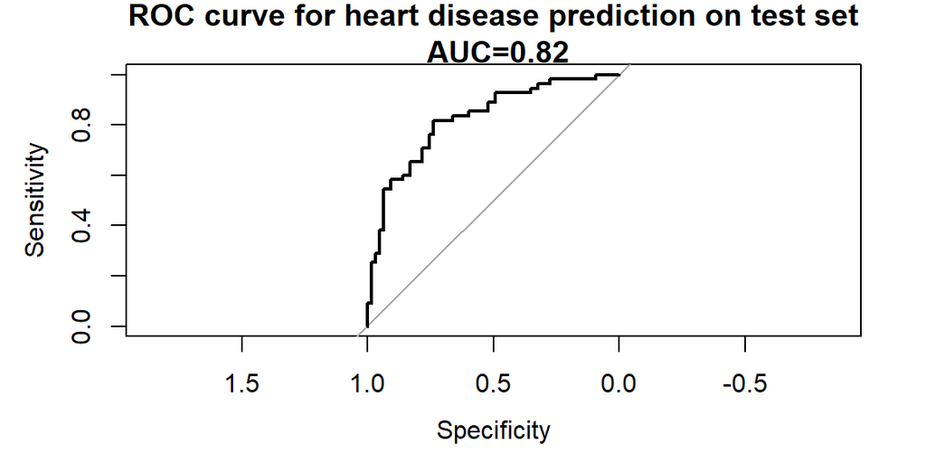

```r
# Plot curve
plot(roc_obj, main = paste0("ROC curve for heart disease prediction on test set\n AUC=",
                            round(auc(roc_obj),2)))
```

# LDA Example: Training Set Performance

- Looking back at training set performance, expect this to be biased upward

```r
# Add in train set predictions
heart_data_train$estimated_prob_heart_disease <-
  predict(lda_fit, newdata=heart_data_train, type = "prob")$Yes

heart_data_train <-
  heart_data_train %>%
  mutate(pred_heart_disease =
           relevel(factor(ifelse(estimated_prob_heart_disease>0.5, "Yes", "No")),
                   ref = "No"))

# Compute confusion matrix
confusionMatrix(data = heart_data_train$pred_heart_disease,
                reference = heart_data_train$heart_disease,
                positive = "Yes")
```

```
## Confusion Matrix and Statistics
##
##           Reference
## Prediction No Yes
##        No  88  24
##        Yes 11  60
##
##                Accuracy : 0.8087
##                  95% CI : (0.7442, 0.863)
##     No Information Rate : 0.541
##     P-Value [Acc > NIR] : 2.987e-14
##
##                   Kappa : 0.6103
##
##  Mcnemar's Test P-Value : 0.04252
##
##             Sensitivity : 0.7143
##             Specificity : 0.8889
##          Pos Pred Value : 0.8451
##          Neg Pred Value : 0.7857
##              Prevalence : 0.4590
##          Detection Rate : 0.3279
##    Detection Prevalence : 0.3880
##       Balanced Accuracy : 0.8016
##
##        'Positive' Class : Yes
##
```

# LDA Example: Training Set Performance

- Training set ROC curve:

```r
# Using pROC, add ROC curve using estimated probabilities of heart disease in test set
roc_obj <-
  roc(response = heart_data_train$heart_disease,
    predictor = heart_data_train$estimated_prob_heart_disease)

# Print obj
roc_obj
```

```
##
## Call:
## roc.default(response = heart_data_train$heart_disease, predictor = heart_data_train$estimated_prob_heart_disease)
##
## Data: heart_data_train$estimated_prob_heart_disease in 99 controls (heart_data_train$heart_disease No) < 84 cases (heart_data_train$heart_disease Yes).
## Area under the curve: 0.882
```

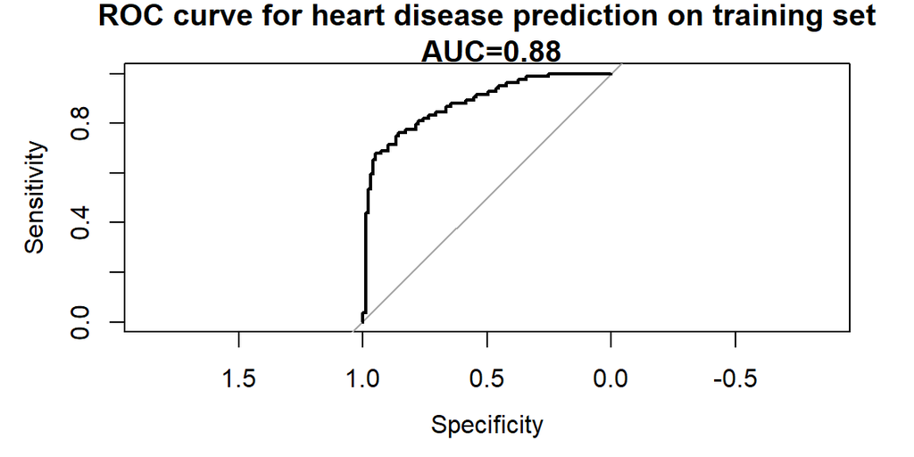

```r
# Plot curve
plot(roc_obj, main = paste0("ROC curve for heart disease prediction on training set\n AUC=",
                            round(auc(roc_obj),2)))
```

# Other forms of discriminant analysis

- **Recall** starting formula for posterior class probabilities:

$$\text{Pr}(Y=k|X=x)=\frac{f(x|k)*\text{Pr}(Y=k)}{\sum_{l=1}^{K} f(x|l)*\text{Pr}(Y=l)}$$

- For LDA, used Normal densities for $f(x|k)$, but could use different distribution to obtain different model
- For LDA, under Normal density model, also assumed $\Sigma_k=\Sigma$ for all $k$ (classes)
  - That is, assumed all classes have same covariance matrix for features
  - May not be reasonable
  - Normal densities but different $\Sigma_k$ om each class $\rightarrow$ **quadratic discriminant analysis**
  - If we additional assume features on independent in each class, i.e. $f(x|k)=\prod_{j=1}^pf(x_j|k)$, obtain **naive Bayes**

# QDA Example

- Again, heart disease example
- **NOTE**: Do our features meet the normal distribution assumption?

```r
# Train
qda_fit <- train(heart_disease~Age+Sex+Chest_Pain+Resting_Blood_Pressure+Colestrol+
                MAX_Heart_Rate+Exercised_Induced_Angina,
                data = heart_data_train, method = "qda")

# Add in test set predictions
heart_data_test$estimated_prob_heart_disease <-
  predict(qda_fit, newdata=heart_data_test, type = "prob")$Yes

heart_data_test <-
  heart_data_test %>%
  mutate(pred_heart_disease =
           relevel(factor(ifelse(estimated_prob_heart_disease>0.5, "Yes", "No")),
                   ref = "No"))

# Compute confusion matrix
confusionMatrix(data = heart_data_test$pred_heart_disease,
                reference = heart_data_test$heart_disease,
                positive = "Yes")
```

```
## Confusion Matrix and Statistics
##
##           Reference
## Prediction No Yes
##        No  55  19
##        Yes 10  36
##
##                Accuracy : 0.7583
##                  95% CI : (0.6717, 0.8318)
##     No Information Rate : 0.5417
##     P-Value [Acc > NIR] : 7.725e-07
##
##                   Kappa : 0.5071
##
##  Mcnemar's Test P-Value : 0.1374
##
##             Sensitivity : 0.6545
##             Specificity : 0.8462
##          Pos Pred Value : 0.7826
##          Neg Pred Value : 0.7432
##              Prevalence : 0.4583
##          Detection Rate : 0.3000
##    Detection Prevalence : 0.3833
##       Balanced Accuracy : 0.7503
##
##        'Positive' Class : Yes
##
```

# QDA Example: Varying Threshold

- Test set ROC curve

```r
# Using pROC, add ROC curve using estimated probabilities of heart disease in test set
roc_obj <-
  roc(response = heart_data_test$heart_disease,
    predictor = heart_data_test$estimated_prob_heart_disease)

# Print obj
roc_obj
```

```
##
## Call:
## roc.default(response = heart_data_test$heart_disease, predictor = heart_data_test$estimated_prob_heart_disease)
##
## Data: heart_data_test$estimated_prob_heart_disease in 65 controls (heart_data_test$heart_disease No) < 55 cases (heart_data_test$heart_disease Yes).
## Area under the curve: 0.8285
```

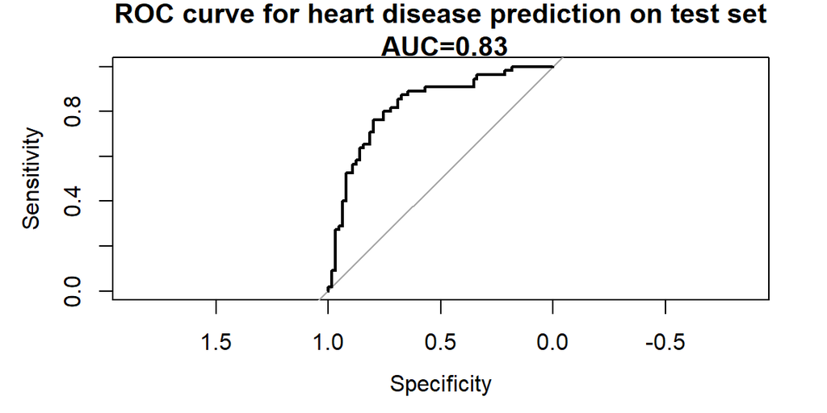

```r
# Plot curve
plot(roc_obj, main = paste0("ROC curve for heart disease prediction on test set\n AUC=",
                            round(auc(roc_obj),2)))
```

# Discriminant analysis summary

- **General rule**:

$$\hat{y_0}=\underset{k=1,\ldots,K}{\operatorname{argmax}}\frac{f(x_0|k)*\text{Pr}(Y=k)}{\sum_{l=1}^{K} f(x_0|l)*\text{Pr}(Y=l)}=\underset{k=1,\ldots,K}{\operatorname{argmax}}f(x_0|k)*\text{Pr}(Y=k)$$

- LDA: assume all $f(x|k)\sim \text{Multivariate Normal}(\mu_k, \Sigma)$ for $k=1,\ldots,K$
- QDA: assume $f(x|k)\sim \text{Multivariate Normal}(\mu_k, \Sigma_k)$ for $k=1,\ldots,K$
  - Can fit QDA in `caret` package with `train` function using `method="qda"`

# Song of the session

[Bad Boy by BIGBANG](https://www.youtube.com/watch?v=1qnV55LUFVM)

[Blue by BIGBANG](https://www.youtube.com/watch?v=2GRP1rkE4O0)

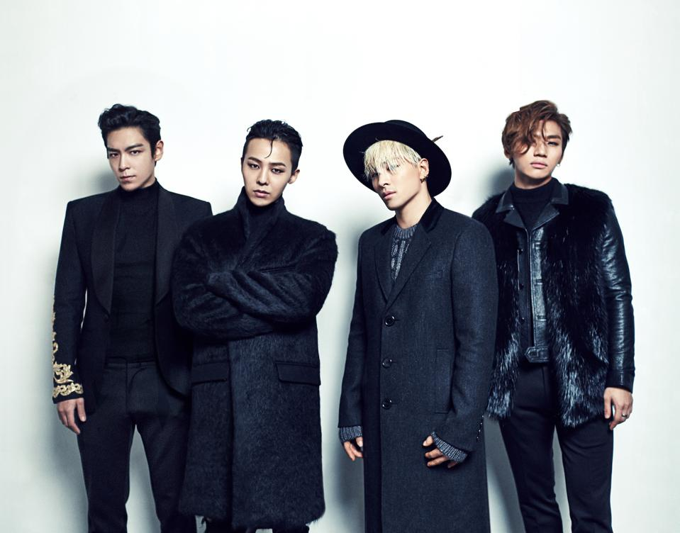